# data summary report

2025-04-07

This report provides an overview of the tree ring data’s quality and characteristics at four levels:

```
1. project: Data Completeness: Assessment of missing or incomplete data of the whole data;
2. project-species: Data Summary: Summary statistics and descriptions;
3. project-species-site: data summary tables and series graphing;
4. project-species-site-radii: Correlation Analysis and quality assessment.
```

project name: **Bijay data**

selected reports: **1, 2, 3, 4**

### data completeness

This table presents the completeness of each variable of the whole dataset as a percentage. A value of 0 indicates no effective data. Please carefully verify that all required data has been included in the submission.

| var | pct |
| --- | --- |
| tr1_submission_id | 100 |
| tr1_project_name | 100 |
| tr1_description | 0 |
| tr1_year_range | 100 |
| tr1_reference | 0 |
| tr1_open_data | 100 |
| tr1_contact1 | 0 |
| tr1_contact2 | 0 |
| tr2_site_id | 100 |
| tr2_latitude | 100 |
| tr2_longitude | 100 |
| tr2_datasource | 0 |
| tr2_investigators | 0 |

| var | pct |
| --- | --- |
| tr2_province_iso_code | 0 |
| tr3_tree_id | 100 |
| tr3_species | 100 |
| tr4_meas_no | 0 |
| tr4_meas_date | 100 |
| tr4_status | 0 |
| tr4_dbh_cm | 0 |
| tr4_ht_tot_m | 0 |
| tr5_sample_id | 100 |
| tr5_sample_type | 0 |
| tr5_sample_ht_m | 0 |
| tr5_sample_diameter_cm | 0 |

| var | pct |
| --- | --- |
| tr6_radius_id | 100 |
| tr6_cofecha_id | 0 |
| tr6_ring_meas_method | 0 |
| tr6_crossdating_visual | 0 |
| tr6_crossdating_validation | 0 |
| tr6_age_corrected | 0 |
| tr6_bark_thickness_mm | 0 |
| tr6_radius_inside_cm | 0 |
| tr6_dtc_measured_mm | 0 |
| tr6_dtc_estimated_mm | 0 |
| tr6_rw_ystart | 100 |
| tr6_rw_yend | 100 |
| tr6_comments | 0 |

### Data Summary (Species)

This section presents key summary statistics, including spatial and temporal ranges, summary of ring width measurements, series length, etc., categorized by species.

In this dataset, there’re 2 species: Dead, Alive

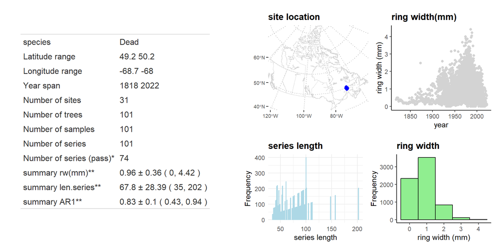

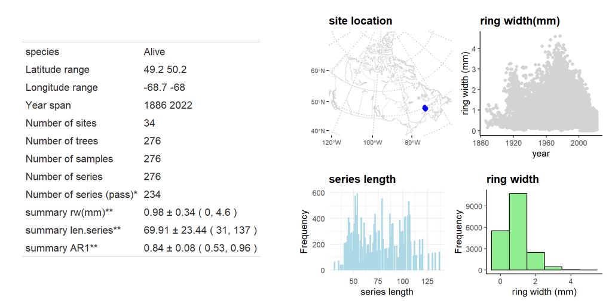

*Number of series that passed the test of CFS_qa() on differentiated series

**The values refer to mean ± sd (min, max)

### site-level data summary

This section presents site-level data summaries, including a figure showing ring width measurements over time and a table with key statistics.

##### Dead on ring width measurement

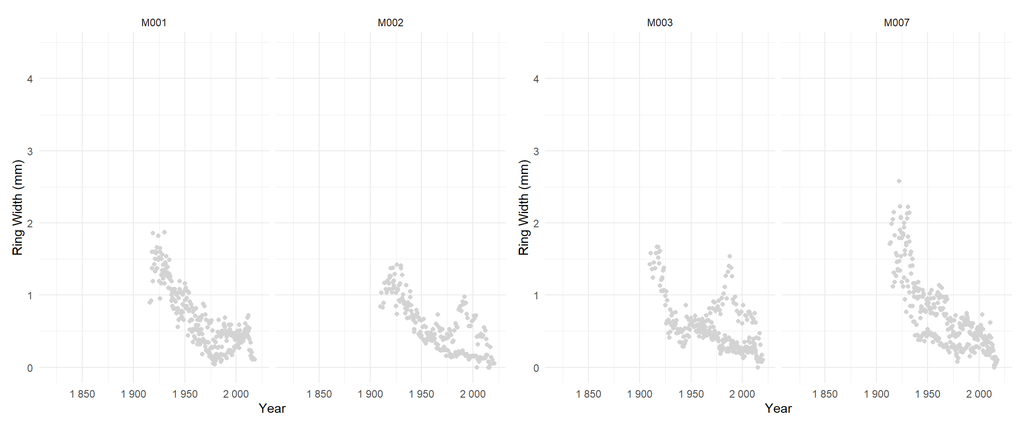

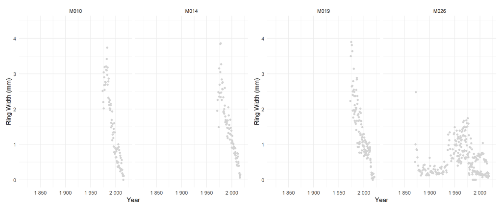

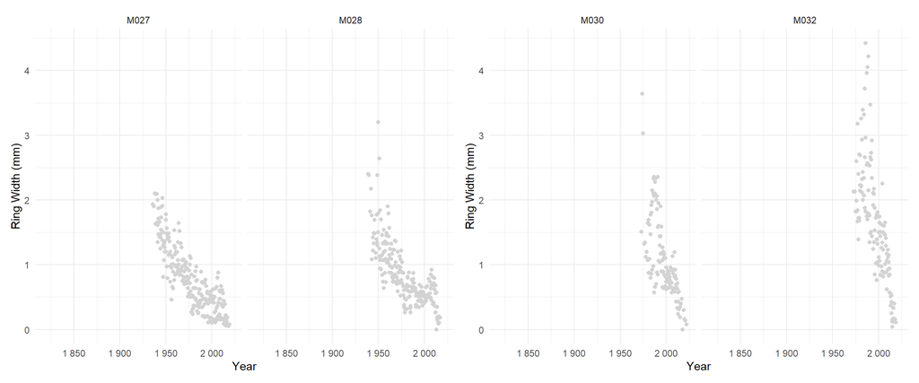

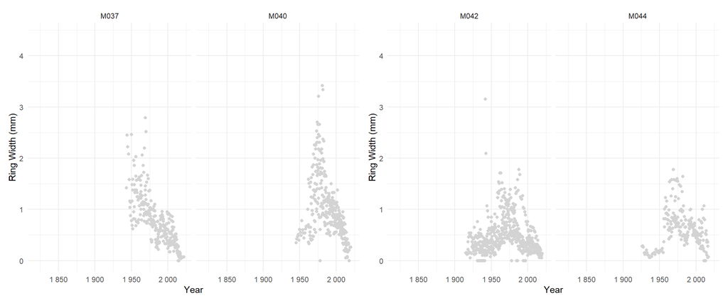

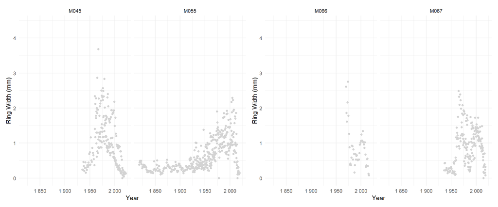

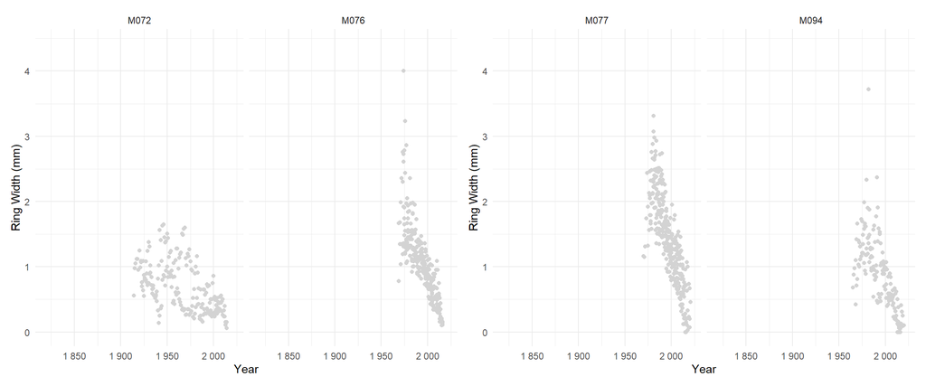

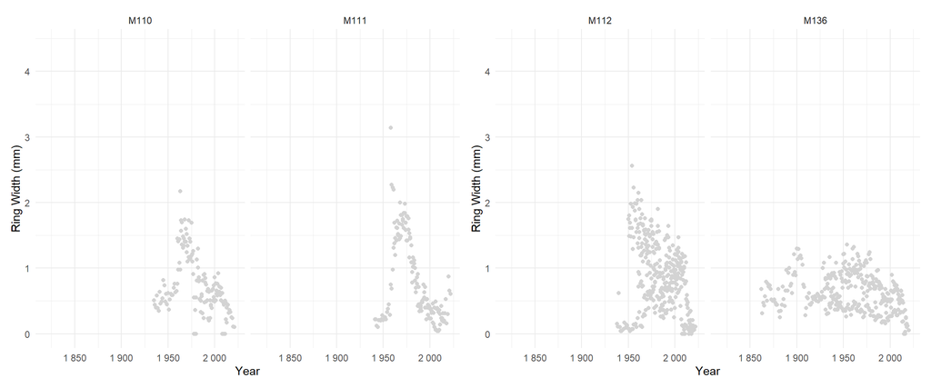

##### Alive on ring width measurement

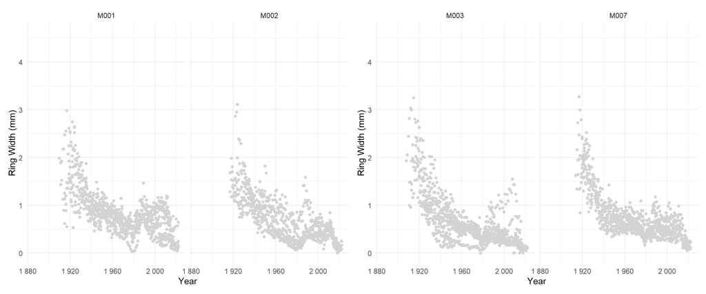

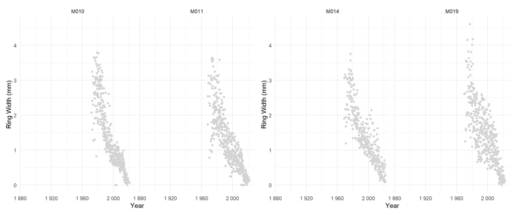

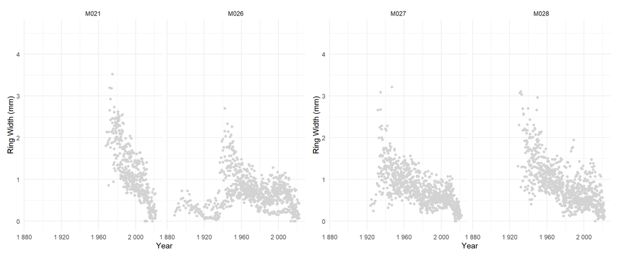

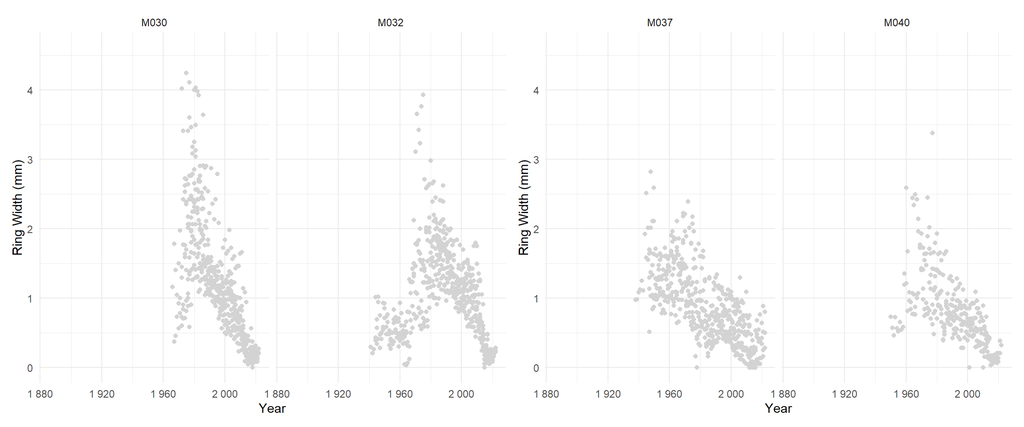

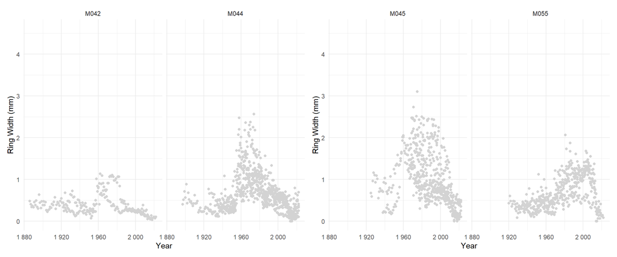

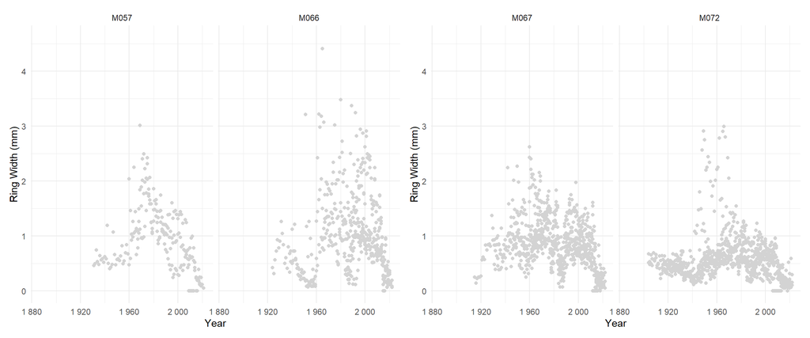

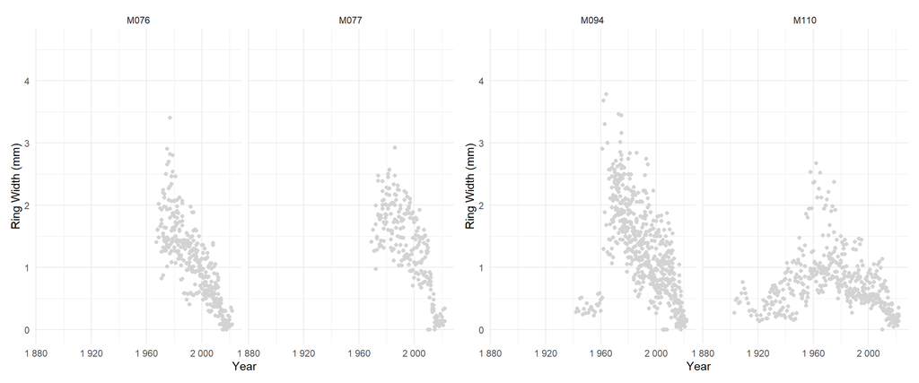

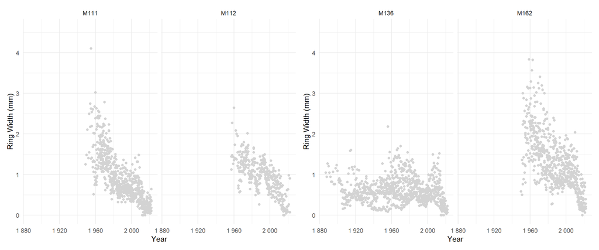

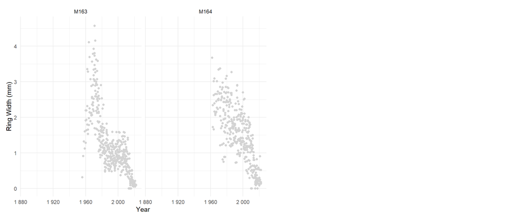

This table provides a site-level summary, including the series length, raw ring width measurements, the median ring width, the median ring width of its 6 closest neighbors, and the ratio between them. This offers insights into potential outliers caused by scaling issues.

Dead

| site_id | lon | lat | Nb. trees | len.series** | rw(mm)** | median rw(mm) | neigh median rw(mm) | ratio_rw* |
| --- | --- | --- | --- | --- | --- | --- | --- | --- |
| M001 | -68.1658 | 49.7295 | 3 | 97 ± 3.46 ( 93, 99 ) | 0.67 ± 0.06 ( 0.04, 1.87 ) | 0.5000 | 0.8300 | 0.6 |
| M002 | -68.1637 | 49.7282 | 2 | 106 ± 8.49 ( 100, 112 ) | 0.55 ± 0.15 ( 0, 1.42 ) | 0.4450 | 0.8300 | 0.5 |
| M003 | -68.1694 | 49.7293 | 3 | 90.33 ± 24.42 ( 63, 110 ) | 0.6 ± 0.14 ( 0, 1.67 ) | 0.4700 | 0.8300 | 0.6 |
| M007 | -68.1701 | 49.7310 | 3 | 101 ± 4 ( 97, 105 ) | 0.74 ± 0.15 ( 0, 2.58 ) | 0.7200 | 0.7200 | 1.0 |
| M010 | -67.9730 | 49.5770 | 2 | 41.5 ± 2.12 ( 40, 43 ) | 1.5 ± 0.14 ( 0, 3.74 ) | 1.3300 | 0.7550 | 1.8 |
| M014 | -67.9847 | 49.5560 | 2 | 44.5 ± 3.54 ( 42, 47 ) | 1.49 ± 0.02 ( 0.06, 3.86 ) | 1.4000 | 0.7550 | 1.9 |
| M019 | -67.9895 | 49.5305 | 3 | 43.67 ± 3.51 ( 40, 47 ) | 1.32 ± 0.3 ( 0, 3.9 ) | 1.0800 | 0.7550 | 1.4 |
| M026 | -67.9714 | 49.4540 | 3 | 93.67 ± 47.18 ( 63, 148 ) | 0.63 ± 0.24 ( 0, 2.48 ) | 0.3700 | 0.9250 | 0.4 |
| M027 | -67.9772 | 49.4594 | 3 | 79.33 ± 2.08 ( 77, 81 ) | 0.79 ± 0.11 ( 0.05, 2.1 ) | 0.7700 | 0.9100 | 0.8 |
| M028 | -67.9780 | 49.4573 | 3 | 73.33 ± 5.69 ( 67, 78 ) | 0.84 ± 0.05 ( 0, 3.2 ) | 0.7400 | 0.9250 | 0.8 |
| M030 | -68.2170 | 49.8352 | 3 | 39.33 ± 2.89 ( 36, 41 ) | 1.09 ± 0.12 ( 0, 3.64 ) | 0.9400 | 0.6100 | 1.5 |
| M032 | -68.2160 | 49.8394 | 3 | 43.33 ± 1.15 ( 42, 44 ) | 1.66 ± 0.34 ( 0.04, 4.42 ) | 1.6350 | 0.6100 | 2.7 |
| M037 | -68.7399 | 49.8019 | 4 | 68.5 ± 5.8 ( 61, 75 ) | 0.8 ± 0.06 ( 0, 2.79 ) | 0.7100 | 0.7900 | 0.9 |
| M040 | -68.7402 | 49.8011 | 6 | 54.83 ± 10.68 ( 47, 76 ) | 1.02 ± 0.21 ( 0, 3.42 ) | 0.8550 | 0.7175 | 1.2 |
| M042 | -68.3719 | 49.3233 | 6 | 92.17 ± 9.02 ( 77, 100 ) | 0.49 ± 0.14 ( 0, 3.15 ) | 0.4050 | 0.9600 | 0.4 |
| M044 | -68.3709 | 49.3227 | 3 | 70 ± 18.36 ( 57, 91 ) | 0.64 ± 0.18 ( 0, 1.78 ) | 0.6300 | 0.9600 | 0.7 |
| M045 | -68.3799 | 49.3121 | 3 | 66.67 ± 17.21 ( 53, 86 ) | 1.06 ± 0.31 ( 0, 3.68 ) | 0.9500 | 0.8300 | 1.1 |
| M055 | -68.3803 | 49.3086 | 3 | 130.33 ± 62.31 ( 89, 202 ) | 0.73 ± 0.24 ( 0, 2.29 ) | 0.6900 | 0.9600 | 0.7 |
| M066 | -68.5532 | 49.1510 | 1 | 47 ± NA ( 47, 47 ) | 0.87 ± NA ( 0.08, 2.75 ) | 0.6900 | 0.7625 | 0.9 |
| M067 | -68.5505 | 49.1524 | 3 | 64 ± 20.52 ( 43, 84 ) | 0.94 ± 0.28 ( 0, 2.49 ) | 0.8350 | 0.6900 | 1.2 |
| M072 | -68.2492 | 49.4025 | 2 | 97 ± 5.66 ( 93, 101 ) | 0.7 ± 0.25 ( 0.06, 1.65 ) | 0.6250 | 0.8200 | 0.8 |
| M076 | -68.2581 | 49.4329 | 6 | 43.67 ± 1.75 ( 41, 46 ) | 1.09 ± 0.17 ( 0.1, 4 ) | 1.0200 | 0.6600 | 1.5 |
| M077 | -68.2600 | 49.4343 | 8 | 39.38 ± 3.96 ( 35, 46 ) | 1.4 ± 0.11 ( 0, 3.31 ) | 1.3900 | 0.6600 | 2.1 |
| M094 | -68.5954 | 49.7016 | 3 | 49.67 ± 4.93 ( 44, 53 ) | 0.92 ± 0.09 ( 0, 3.72 ) | 0.9800 | 0.7825 | 1.3 |
| M110 | -68.6187 | 49.4320 | 2 | 70.5 ± 23.33 ( 54, 87 ) | 0.76 ± 0.13 ( 0, 2.17 ) | 0.6750 | 0.8200 | 0.8 |
| M111 | -68.6220 | 49.4311 | 2 | 70 ± 16.97 ( 58, 82 ) | 0.83 ± 0.21 ( 0.04, 3.14 ) | 0.5575 | 0.8200 | 0.7 |
| M112 | -68.6064 | 49.4168 | 5 | 66.2 ± 12.15 ( 54, 84 ) | 0.9 ± 0.39 ( 0, 2.56 ) | 1.0400 | 0.6525 | 1.6 |
| M136 | -68.3880 | 50.1732 | 3 | 112.67 ± 38.4 ( 90, 157 ) | 0.65 ± 0.13 ( 0, 1.36 ) | 0.7250 | 0.6100 | 1.2 |
| M162 | -68.2717 | 49.2179 | 3 | 58 ± 3.61 ( 54, 61 ) | 1.54 ± 0.4 ( 0, 3.46 ) | 1.5100 | 0.8200 | 1.8 |
| M163 | -68.2770 | 49.2191 | 3 | 45.33 ± 4.93 ( 42, 51 ) | 1.07 ± 0.02 ( 0.06, 3.01 ) | 1.0400 | 0.8200 | 1.3 |
| M164 | -68.2762 | 49.2181 | 2 | 52.5 ± 4.95 ( 49, 56 ) | 1.12 ± 0.22 ( 0.06, 2.52 ) | 0.9700 | 0.8200 | 1.2 |

Alive

| site_id | lon | lat | Nb. trees | len.series** | rw(mm)** | median rw(mm) | neigh median rw(mm) | ratio_rw* |
| --- | --- | --- | --- | --- | --- | --- | --- | --- |
| M001 | -68.1658 | 49.7295 | 9 | 101.22 ± 11.3 ( 79, 113 ) | 0.81 ± 0.1 ( 0.02, 2.98 ) | 0.7600 | 0.82250 | 0.9 |
| M002 | -68.1637 | 49.7282 | 7 | 101.86 ± 3.89 ( 96, 106 ) | 0.7 ± 0.15 ( 0, 3.11 ) | 0.5000 | 0.90500 | 0.6 |
| M003 | -68.1694 | 49.7293 | 9 | 104.11 ± 6.45 ( 95, 114 ) | 0.63 ± 0.17 ( 0, 3.24 ) | 0.5300 | 0.90500 | 0.6 |
| M007 | -68.1701 | 49.7310 | 9 | 102.11 ± 7.82 ( 82, 108 ) | 0.72 ± 0.11 ( 0.04, 3.27 ) | 0.5950 | 0.90500 | 0.7 |
| M010 | -67.9730 | 49.5770 | 10 | 42.9 ± 2.13 ( 39, 46 ) | 1.36 ± 0.22 ( 0, 3.79 ) | 1.0500 | 0.97625 | 1.1 |
| M011 | -67.9725 | 49.5739 | 10 | 48.6 ± 3.84 ( 42, 54 ) | 1.17 ± 0.25 ( 0, 3.64 ) | 0.9025 | 1.05000 | 0.9 |
| M014 | -67.9847 | 49.5560 | 7 | 49.14 ± 3.48 ( 45, 54 ) | 1.39 ± 0.17 ( 0.08, 3.75 ) | 1.2700 | 0.97625 | 1.3 |
| M019 | -67.9895 | 49.5305 | 10 | 46.5 ± 3.98 ( 41, 52 ) | 1.37 ± 0.41 ( 0, 4.6 ) | 1.3775 | 0.97625 | 1.4 |
| M021 | -67.9903 | 49.5282 | 10 | 44.9 ± 6.26 ( 31, 54 ) | 1.15 ± 0.24 ( 0, 3.52 ) | 1.0500 | 0.97625 | 1.1 |
| M026 | -67.9714 | 49.4540 | 9 | 90.44 ± 21.71 ( 71, 133 ) | 0.69 ± 0.18 ( 0, 2.7 ) | 0.6900 | 0.97625 | 0.7 |
| M027 | -67.9772 | 49.4594 | 10 | 85.9 ± 6.59 ( 74, 98 ) | 0.78 ± 0.1 ( 0, 3.21 ) | 0.6850 | 0.97625 | 0.7 |
| M028 | -67.9780 | 49.4573 | 10 | 83.6 ± 7.55 ( 71, 94 ) | 0.86 ± 0.13 ( 0, 3.1 ) | 0.7400 | 0.97625 | 0.8 |
| M030 | -68.2170 | 49.8352 | 10 | 49 ± 4.22 ( 44, 55 ) | 1.21 ± 0.34 ( 0, 4.24 ) | 1.0900 | 0.67750 | 1.6 |
| M032 | -68.2160 | 49.8394 | 9 | 58.22 ± 17.53 ( 37, 79 ) | 1.09 ± 0.21 ( 0, 3.93 ) | 1.1200 | 0.67750 | 1.7 |
| M037 | -68.7399 | 49.8019 | 7 | 71.71 ± 6.47 ( 59, 76 ) | 0.88 ± 0.2 ( 0, 2.82 ) | 0.7900 | 0.78000 | 1.0 |
| M040 | -68.7402 | 49.8011 | 5 | 56.6 ± 11.55 ( 42, 73 ) | 0.82 ± 0.16 ( 0, 3.38 ) | 0.7700 | 0.79000 | 1.0 |
| M042 | -68.3719 | 49.3233 | 2 | 117 ± 28.28 ( 97, 137 ) | 0.4 ± 0.06 ( 0.03, 1.13 ) | 0.3200 | 0.87250 | 0.4 |
| M044 | -68.3709 | 49.3227 | 10 | 82 ± 20.6 ( 57, 126 ) | 0.68 ± 0.13 ( 0, 2.56 ) | 0.6100 | 0.87250 | 0.7 |
| M045 | -68.3799 | 49.3121 | 9 | 62.56 ± 16.34 ( 51, 97 ) | 1.03 ± 0.34 ( 0, 3.1 ) | 0.7800 | 0.79250 | 1.0 |
| M055 | -68.3803 | 49.3086 | 6 | 78 ± 20.03 ( 43, 103 ) | 0.73 ± 0.23 ( 0, 2.06 ) | 0.6200 | 0.87250 | 0.7 |
| M057 | -68.3849 | 49.3104 | 3 | 68 ± 18.73 ( 53, 89 ) | 1.01 ± 0.28 ( 0, 3.01 ) | 1.0300 | 0.70000 | 1.5 |
| M066 | -68.5532 | 49.1510 | 8 | 57.5 ± 24.33 ( 35, 99 ) | 1.13 ± 0.35 ( 0, 4.41 ) | 1.0775 | 0.70000 | 1.5 |
| M067 | -68.5505 | 49.1524 | 10 | 76.2 ± 15.68 ( 57, 105 ) | 0.85 ± 0.15 ( 0, 2.62 ) | 0.8100 | 0.70000 | 1.2 |
| M072 | -68.2492 | 49.4025 | 9 | 96.56 ± 18.34 ( 71, 119 ) | 0.58 ± 0.22 ( 0, 2.99 ) | 0.5100 | 0.70000 | 0.7 |
| M076 | -68.2581 | 49.4329 | 7 | 50.14 ± 3.53 ( 45, 54 ) | 1.07 ± 0.1 ( 0, 3.4 ) | 1.1200 | 0.61500 | 1.8 |
| M077 | -68.2600 | 49.4343 | 5 | 49.2 ± 3.77 ( 43, 53 ) | 1.32 ± 0.25 ( 0, 2.92 ) | 1.4150 | 0.61500 | 2.3 |
| M094 | -68.5954 | 49.7016 | 10 | 56.8 ± 8.26 ( 48, 77 ) | 1.26 ± 0.23 ( 0, 3.78 ) | 1.1150 | 0.79000 | 1.4 |
| M110 | -68.6187 | 49.4320 | 5 | 87 ± 26.36 ( 51, 120 ) | 0.77 ± 0.28 ( 0, 2.67 ) | 0.6250 | 0.78500 | 0.8 |
| M111 | -68.6220 | 49.4311 | 11 | 63.09 ± 5.03 ( 57, 71 ) | 0.89 ± 0.19 ( 0, 4.1 ) | 0.7900 | 0.87375 | 0.9 |
| M112 | -68.6064 | 49.4168 | 6 | 58.17 ± 5.15 ( 52, 64 ) | 0.94 ± 0.08 ( 0, 2.64 ) | 0.9675 | 0.70250 | 1.4 |
| M136 | -68.3880 | 50.1732 | 9 | 95.11 ± 24.99 ( 67, 130 ) | 0.64 ± 0.16 ( 0, 2.18 ) | 0.5900 | 0.67750 | 0.9 |
| M162 | -68.2717 | 49.2179 | 10 | 65.9 ± 5.57 ( 58, 72 ) | 1.29 ± 0.24 ( 0, 3.83 ) | 1.2175 | 0.70000 | 1.7 |
| M163 | -68.2770 | 49.2191 | 8 | 55.62 ± 6.82 ( 48, 67 ) | 1.23 ± 0.23 ( 0, 4.57 ) | 0.9650 | 0.70000 | 1.4 |
| M164 | -68.2762 | 49.2181 | 7 | 50.14 ± 10.78 ( 31, 61 ) | 1.52 ± 0.16 ( 0, 3.67 ) | 1.6200 | 0.70000 | 2.3 |

*ratio between median of rw of the site and median of rw of its 6 nearest neighbors.  
**The values refer to mean ± sd (min, max)

### Correlation and quality assessment code

This table provides a summary for each series, including raw ring width measurements, autocorrelation, correlation with master chronology for both raw and differentiated data, and quality assessment code (qa_code) which was derived from the CFS_qa() function. The master chronology includes all the series with qa_code ‘pass’.

Dead

| site_id | radius_id | year from | year to | len series | raw AR1* | raw corr_mean*& | trt AR1** | trt corr_mean**& | qa_code**% |
| --- | --- | --- | --- | --- | --- | --- | --- | --- | --- |
| M001 | M001E012 | 1926 | 2018 | 93 | 0.88 | 0.17 ( 0.1 ) | -0.24 | 0.28 ( 0.01 ) | pass |
| M001 | M001E027 | 1916 | 2014 | 99 | 0.94 | -0.08 ( 0.46 ) | -0.43 | 0.38 ( 0 ) | pass |
| M001 | M001E029 | 1918 | 2016 | 99 | 0.92 | 0.05 ( 0.6 ) | -0.08 | 0.39 ( 0 ) | pass |
| M002 | M002E016 | 1918 | 2017 | 100 | 0.93 | 0.13 ( 0.2 ) | -0.43 | 0.28 ( 0 ) | pass |
| M002 | M002E036 | 1910 | 2021 | 112 | 0.86 | 0.38 ( 0 ) | -0.38 | 0.47 ( 0 ) | pass |
| M003 | M003E026 | 1958 | 2020 | 63 | 0.78 | 0.53 ( 0 ) | -0.30 | 0.36 ( 0 ) | pass |
| M003 | M003E031 | 1918 | 2015 | 98 | 0.88 | 0.31 ( 0 ) | -0.18 | 0.5 ( 0 ) | pass |
| M003 | M003E038 | 1910 | 2019 | 110 | 0.94 | 0.31 ( 0 ) | -0.06 | 0.34 ( 0 ) | pass |
| M007 | M007E008 | 1913 | 2017 | 105 | 0.93 | 0.16 ( 0.1 ) | -0.15 | 0.46 ( 0 ) | pass |
| M007 | M007E015 | 1922 | 2018 | 97 | 0.90 | 0.35 ( 0 ) | -0.02 | 0.45 ( 0 ) | pass |
| M007 | M007E033 | 1916 | 2016 | 101 | 0.94 | 0.22 ( 0.03 ) | -0.20 | 0.53 ( 0 ) | pass |
| M010 | M010E008 | 1974 | 2016 | 43 | 0.94 | 0.82 ( 0 ) | -0.13 | 0.27 ( 0.08 ) | Fail |
| M010 | M010E022 | 1976 | 2015 | 40 | 0.93 | 0.86 ( 0 ) | -0.06 | 0.06 ( 0.7 ) | highpeak |
| M014 | M014E006 | 1975 | 2016 | 42 | 0.84 | 0.91 ( 0 ) | -0.44 | 0.66 ( 0 ) | pass |
| M014 | M014E041 | 1971 | 2017 | 47 | 0.90 | 0.8 ( 0 ) | -0.02 | 0.07 ( 0.65 ) | highpeak |
| M019 | M019E008 | 1978 | 2021 | 44 | 0.86 | 0.83 ( 0 ) | 0.03 | 0.4 ( 0.01 ) | pass |
| M019 | M019E023 | 1976 | 2015 | 40 | 0.83 | 0.81 ( 0 ) | 0.10 | 0.48 ( 0 ) | pass |
| M019 | M019E025 | 1973 | 2019 | 47 | 0.90 | 0.91 ( 0 ) | 0.03 | 0.59 ( 0 ) | pass |
| M026 | M026E024 | 1948 | 2017 | 70 | 0.94 | 0.56 ( 0 ) | -0.20 | 0.39 ( 0 ) | pass |
| M026 | M026E026 | 1955 | 2017 | 63 | 0.90 | 0.85 ( 0 ) | 0.03 | 0.4 ( 0 ) | pass |
| M026 | M026E031 | 1871 | 2018 | 148 | 0.76 | 0.37 ( 0 ) | -0.21 | 0.63 ( 0 ) | pass |
| M027 | M027E037 | 1940 | 2016 | 77 | 0.92 | 0.24 ( 0.03 ) | -0.25 | 0.47 ( 0 ) | pass |
| M027 | M027E045 | 1939 | 2019 | 81 | 0.80 | 0.55 ( 0 ) | -0.09 | 0.43 ( 0 ) | pass |
| M027 | M027E061 | 1936 | 2015 | 80 | 0.90 | 0.22 ( 0.05 ) | -0.17 | 0.38 ( 0 ) | pass |
| M028 | M028E059 | 1949 | 2015 | 67 | 0.84 | 0.3 ( 0.02 ) | -0.08 | 0.59 ( 0 ) | pass |
| M028 | M028E072 | 1943 | 2017 | 75 | 0.85 | 0.42 ( 0 ) | -0.39 | 0.45 ( 0 ) | pass |
| M028 | M028E083 | 1939 | 2016 | 78 | 0.85 | 0.24 ( 0.04 ) | -0.28 | 0.54 ( 0 ) | pass |
| M030 | M030E015 | 1980 | 2015 | 36 | 0.91 | 0.74 ( 0 ) | -0.13 | -0.02 ( 0.89 ) | Fail |
| M030 | M030E044 | 1982 | 2022 | 41 | 0.91 | 0.82 ( 0 ) | -0.23 | -0.05 ( 0.74 ) | Fail |
| M030 | M030E058 | 1973 | 2013 | 41 | 0.67 | 0.74 ( 0 ) | -0.07 | 0.36 ( 0.02 ) | pass |

[output cut: 71 more lines]

Alive

| site_id | radius_id | year from | year to | len series | raw AR1* | raw corr_mean*& | trt AR1** | trt corr_mean**& | qa_code**% |
| --- | --- | --- | --- | --- | --- | --- | --- | --- | --- |
| M001 | M001E001 | 1915 | 2020 | 106 | 0.86 | 0.26 ( 0.01 ) | -0.14 | 0.36 ( 0 ) | pass |
| M001 | M001E003 | 1921 | 2022 | 102 | 0.80 | 0.39 ( 0 ) | -0.09 | 0.48 ( 0 ) | pass |
| M001 | M001E015 | 1944 | 2022 | 79 | 0.73 | -0.08 ( 0.47 ) | -0.21 | 0.53 ( 0 ) | pass |
| M001 | M001E017 | 1932 | 2018 | 87 | 0.79 | 0.26 ( 0.02 ) | -0.25 | 0.42 ( 0 ) | pass |
| M001 | M001E031 | 1919 | 2020 | 102 | 0.88 | 0.42 ( 0 ) | -0.25 | 0.61 ( 0 ) | pass |
| M001 | M001E035 | 1910 | 2022 | 113 | 0.95 | 0.34 ( 0 ) | -0.25 | 0.47 ( 0 ) | pass |
| M001 | M001E040 | 1915 | 2022 | 108 | 0.87 | 0.27 ( 0.01 ) | -0.15 | 0.37 ( 0 ) | pass |
| M001 | M001E042 | 1911 | 2022 | 112 | 0.90 | 0.5 ( 0 ) | -0.10 | 0.47 ( 0 ) | pass |
| M001 | M001E043 | 1921 | 2022 | 102 | 0.90 | 0.26 ( 0.01 ) | -0.30 | 0.57 ( 0 ) | pass |
| M002 | M002E003 | 1920 | 2019 | 100 | 0.94 | 0.16 ( 0.12 ) | -0.10 | 0.5 ( 0 ) | pass |
| M002 | M002E004 | 1922 | 2020 | 99 | 0.91 | 0.15 ( 0.15 ) | -0.27 | 0.44 ( 0 ) | pass |
| M002 | M002E021 | 1924 | 2019 | 96 | 0.89 | 0.29 ( 0 ) | -0.17 | 0.31 ( 0 ) | pass |
| M002 | M002E022 | 1919 | 2019 | 101 | 0.96 | 0.07 ( 0.47 ) | -0.21 | 0.39 ( 0 ) | pass |
| M002 | M002E029 | 1917 | 2022 | 106 | 0.93 | 0.22 ( 0.02 ) | -0.17 | 0.54 ( 0 ) | pass |
| M002 | M002E033 | 1917 | 2022 | 106 | 0.85 | 0.52 ( 0 ) | -0.17 | 0.57 ( 0 ) | pass |
| M002 | M002E039 | 1918 | 2022 | 105 | 0.85 | 0.49 ( 0 ) | -0.18 | 0.44 ( 0 ) | pass |
| M003 | M003E014 | 1911 | 2022 | 112 | 0.95 | 0.35 ( 0 ) | -0.23 | 0.39 ( 0 ) | pass |
| M003 | M003E016 | 1919 | 2019 | 101 | 0.89 | 0.34 ( 0 ) | -0.26 | 0.35 ( 0 ) | pass |
| M003 | M003E017 | 1925 | 2021 | 97 | 0.63 | 0.24 ( 0.02 ) | -0.17 | 0.02 ( 0.85 ) | Fail |
| M003 | M003E019 | 1923 | 2022 | 100 | 0.93 | 0.15 ( 0.13 ) | -0.19 | 0.53 ( 0 ) | pass |
| M003 | M003E028 | 1922 | 2016 | 95 | 0.92 | -0.12 ( 0.25 ) | -0.22 | 0.47 ( 0 ) | pass |
| M003 | M003E035 | 1908 | 2021 | 114 | 0.96 | 0.3 ( 0 ) | -0.32 | 0.43 ( 0 ) | pass |
| M003 | M003E036 | 1917 | 2021 | 105 | 0.89 | 0.35 ( 0 ) | -0.12 | 0.43 ( 0 ) | pass |
| M003 | M003E037 | 1913 | 2019 | 107 | 0.92 | 0.41 ( 0 ) | -0.09 | 0.47 ( 0 ) | pass |
| M003 | M003E040 | 1911 | 2016 | 106 | 0.96 | 0.2 ( 0.04 ) | -0.26 | 0.56 ( 0 ) | pass |
| M007 | M007E001 | 1917 | 2021 | 105 | 0.88 | 0.38 ( 0 ) | -0.08 | 0.31 ( 0 ) | pass |
| M007 | M007E010 | 1920 | 2022 | 103 | 0.90 | 0.38 ( 0 ) | -0.20 | 0.4 ( 0 ) | pass |
| M007 | M007E014 | 1914 | 2021 | 108 | 0.96 | 0.43 ( 0 ) | 0.14 | 0.49 ( 0 ) | pass |
| M007 | M007E018 | 1920 | 2022 | 103 | 0.85 | 0.36 ( 0 ) | -0.11 | 0.6 ( 0 ) | pass |
| M007 | M007E023 | 1915 | 2021 | 107 | 0.95 | 0.35 ( 0 ) | -0.17 | 0.4 ( 0 ) | pass |

[output cut: 246 more lines]

*developed from raw series  
**developed from differentiated series  
&correlation with master chronology, the value represents correlation (p-value)  
%qa_code is identified using the current data as reference dataset